# Genome-wide methylation analysis report

# Genome-wide methylation analysis report

- study: Pleural cfDNAm analysis of infection_non_maligvariable
- author: Paul Yousefi
- date: 08 October, 2026

## Parameters

```
## $sig.threshold
## [1] 2.121143e-07
##
## $max.plots
## [1] 10
##
## $qq.inflation.method
## [1] "median"
##
## $practical.threshold
## [1] 2.530921e-05
```

## Sample characteristics

For continuous or ordinal variables, the “mean” column provides the mean and the “sd/%” column the standard deviation of the variable. For categorical variables, the “mean” column provides the number of samples with the given “value” and the “sd/%” column the percentage of samples with the given “value”.

| variable | value | mean | sd.. |
| --- | --- | --- | --- |
| infection_non_malig |  | 0.2627737 | 0.4417557 |
| sv1 |  | -3.070093e-19 | 0.08574929 |
| sv2 |  | 2.319609e-18 | 0.08574929 |
| sv3 |  | 6.615513e-19 | 0.08574929 |
| sv4 |  | -1.156219e-18 | 0.08574929 |
| sv5 |  | -5.807684e-18 | 0.08574929 |
| sv6 |  | -6.918961e-19 | 0.08574929 |
| sv7 |  | -7.94967e-18 | 0.08574929 |
| sv8 |  | 6.294011e-18 | 0.08574929 |
| sv9 |  | 8.857932e-17 | 0.08574929 |
| sv10 |  | 1.1122e-14 | 0.08574929 |

## Covariate associations

### Covariate sv1

statistics

| var1 | var2 | F | p-value | R | p-value |
| --- | --- | --- | --- | --- | --- |
| infection_non_malig | sv1 | 0.2436338 | 0.6223959 | 0.0448697 | 0.6026197 |

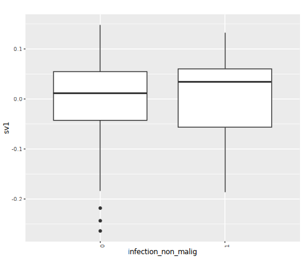

### Covariate sv2

statistics

| var1 | var2 | F | p-value | R | p-value |
| --- | --- | --- | --- | --- | --- |
| infection_non_malig | sv2 | 0.0556253 | 0.8139064 | 0.0117416 | 0.891681 |

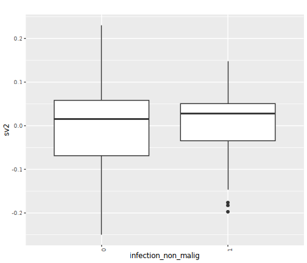

### Covariate sv3

statistics

| var1 | var2 | F | p-value | R | p-value |
| --- | --- | --- | --- | --- | --- |
| infection_non_malig | sv3 | 0.7954808 | 0.3740349 | 0.1190935 | 0.1657104 |

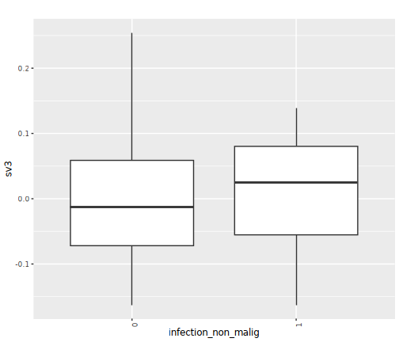

### Covariate sv4

statistics

| var1 | var2 | F | p-value | R | p-value |
| --- | --- | --- | --- | --- | --- |
| infection_non_malig | sv4 | 1.433316 | 0.233322 | 0.1132227 | 0.1877263 |

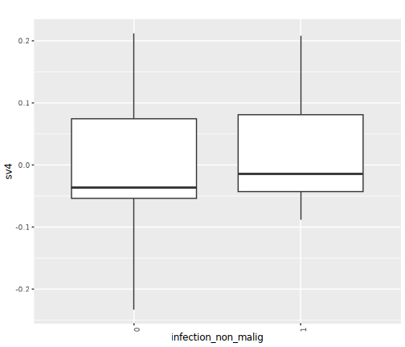

### Covariate sv5

statistics

| var1 | var2 | F | p-value | R | p-value |
| --- | --- | --- | --- | --- | --- |
| infection_non_malig | sv5 | 0.6343261 | 0.4271713 | -0.0381602 | 0.6579661 |

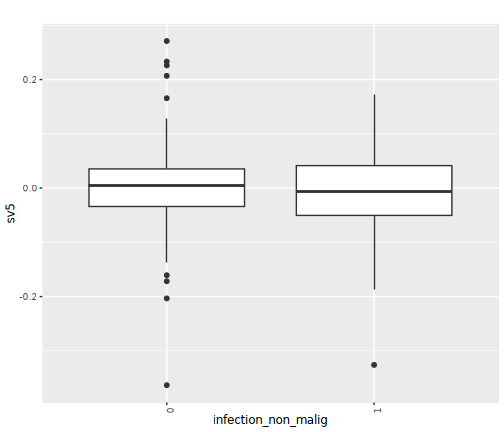

### Covariate sv6

statistics

| var1 | var2 | F | p-value | R | p-value |
| --- | --- | --- | --- | --- | --- |
| infection_non_malig | sv6 | 0.1764704 | 0.6750921 | -0.0436117 | 0.6128387 |

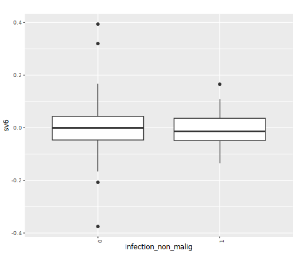

### Covariate sv7

statistics

| var1 | var2 | F | p-value | R | p-value |
| --- | --- | --- | --- | --- | --- |
| infection_non_malig | sv7 | 0.0854518 | 0.7704897 | -0.0591274 | 0.4925062 |

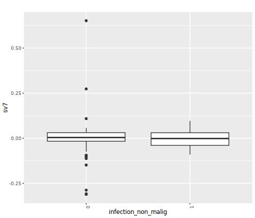

### Covariate sv8

statistics

| var1 | var2 | F | p-value | R | p-value |
| --- | --- | --- | --- | --- | --- |
| infection_non_malig | sv8 | 0.0268013 | 0.8702034 | -0.0289347 | 0.7371431 |

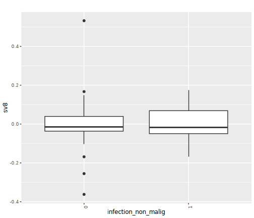

### Covariate sv9

statistics

| var1 | var2 | F | p-value | R | p-value |
| --- | --- | --- | --- | --- | --- |
| infection_non_malig | sv9 | 0.0616577 | 0.8042721 | -0.0448697 | 0.6026197 |

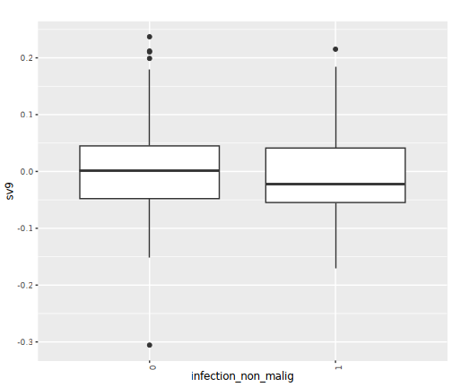

### Covariate sv10

statistics

| var1 | var2 | F | p-value | R | p-value |
| --- | --- | --- | --- | --- | --- |
| infection_non_malig | sv10 | 0.0197107 | 0.8885574 | 0.0029354 | 0.9728426 |

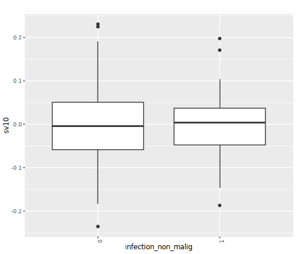

## QQ plots

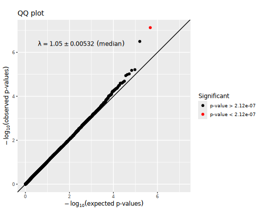

## Manhattan plots

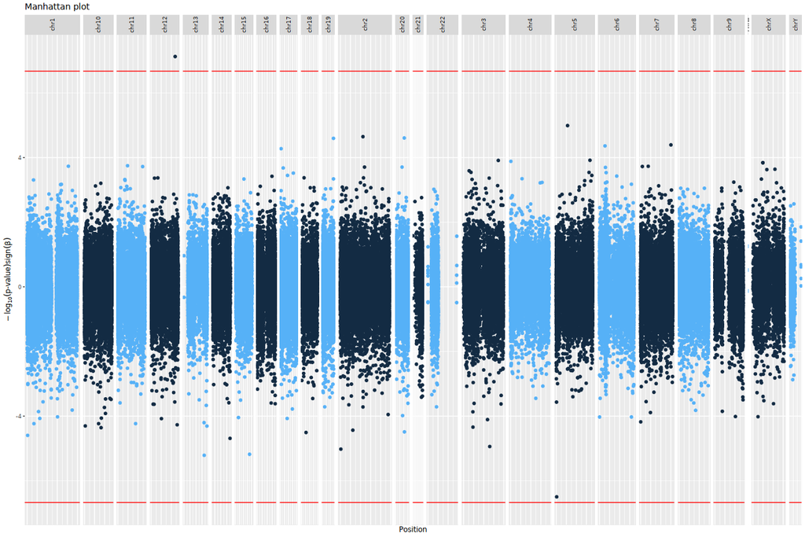

## Significant CpG sites

There were 1 CpG sites with association p-values < 2.1211427 × 10<sup>-7</sup>. These are listed in the file associations.csv.

[output not shown]

Plots of these sites follow, one for each covariate set. “p[lm]” denotes the p-value obtained using a linear model and “p[beta]” the p-value obtained using beta regression.

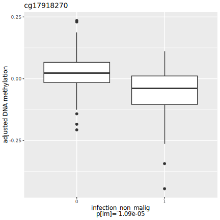

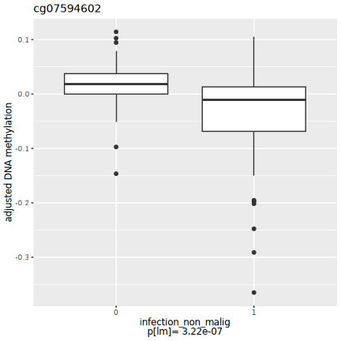

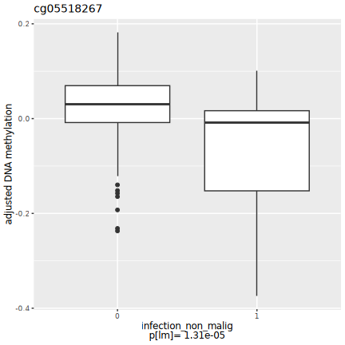

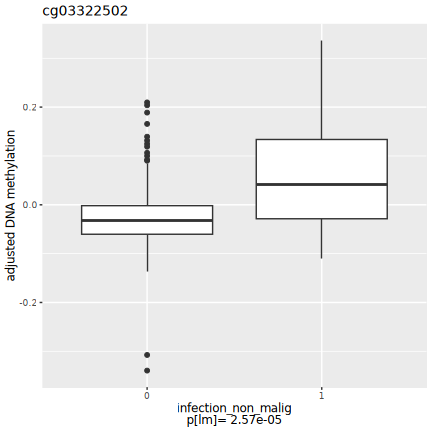

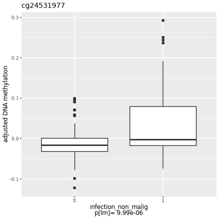

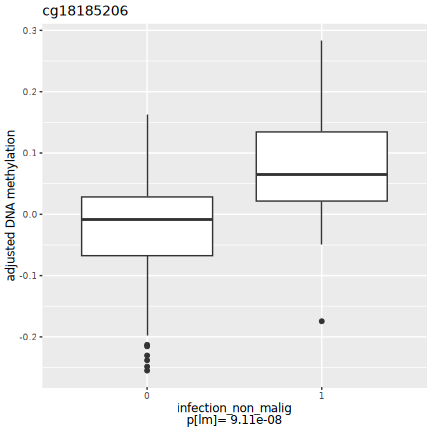

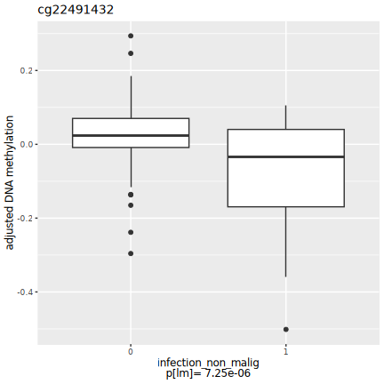

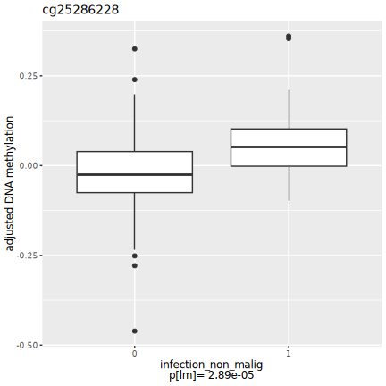

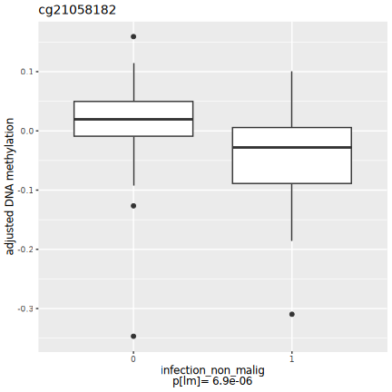

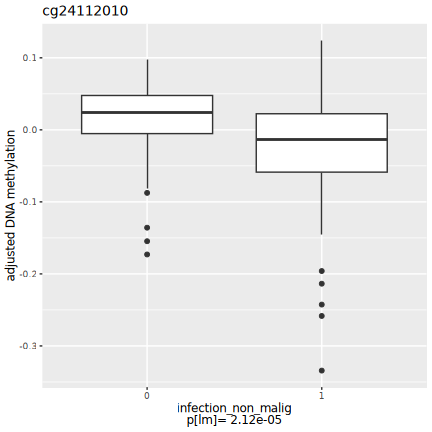

## Selected CpG sites

Number of CpG sites selected: 0.

| chromosome | position | estimate | p.value | p.adjust |
| --- | --- | --- | --- | --- |